# Identifying Biomarkers from an Exposure Variable

Nima S. Hejazi & Alan E. Hubbard

2017-01-16

## Introduction

The `biotmle` R package can be used to isolate biomarkers in two ways: based on the associations of genomic objects with (1) an exposure variable of interest and (2) an outcome variable of interest. In this vignette, we illustrate how to use `biotmle` to isolate and visualize genes associated with an **exposure**, using a data set containing microarray expression measures from an Illumina platform. In the analysis described below, Targeted Minimum Loss-Based Estimation (TMLE) is used to transform the microarray expression values based on the influence curve representation of the Average Treatment Effect (ATE). Following this transformation, the moderated t-statistic of Smyth is used to test for a binary groupwise difference (based on the exposure variable), using the tools provided by the R package `limma`.

## Biomarker Identification

First, we load the `biotmle` package and the (included) `illuminaData` data set:

```r
library(dplyr)
library(biotmle)
data(illuminaData)
"%ni%" = Negate("%in%")
subjIDs <- illuminaData$id
```

In order to perform Targeted Minimum Loss-Based Estimation, we need three separate data structures: (1) *W*, baseline covariates that could potentially confound the association of biomarkers with the exposure of interest; (2) *A*, the exposure of interest; and (3) *Y*, the biomarkers of interest. All values in *W* and *A* must be discretized. We demonstrate the process of creating these separate data structures with the `illuminaData` data set below:

```r
# W - age, sex, smoking
W <- illuminaData %>%
  dplyr::select(which(colnames(.) %in% c("age", "sex", "smoking"))) %>%
  dplyr::mutate(
    age = as.numeric((age > quantile(age, 0.25))),
    sex = I(sex),
    smoking = I(smoking)
  )


# A - benzene exposure (discretized)
A <- illuminaData %>%
  dplyr::select(which(colnames(.) %in% c("benzene")))
A <- A[, 1]


# Y - genes
Y <- illuminaData %>%
  dplyr::select(which(colnames(.) %ni% c("age", "sex", "smoking", "benzene",
                                         "id")))
geneIDs <- colnames(Y)
```

After creating *W*, *A*, and *Y*, the TMLE-based biomarker discovery process can be invoked using the `biomarkertmle` function. The procedure is quite resource-intensive because it evaluates the association of each individual potential biomarker (of which there are over 20,000 in the included data set) with exposure of interest *A*, while accounting for potential confounding based on the covariates included in *W*. We demonstrate the necessary syntax for calling `biomarkertmle` below:

```r
biomarkerTMLEout <- biomarkertmle(Y = Y,
                                  W = W,
                                  A = A,
                                  type = "exposure",
                                  parallel = TRUE,
                                  family = "gaussian",
                                  g_lib = c("SL.glmnet", "SL.randomForest",
                                            "SL.polymars", "SL.mean"),
                                  Q_lib = c("SL.glmnet", "SL.randomForest",
                                            "SL.nnet", "SL.mean")
                                 )
```

The output of `biomarkertmle()` is an object of class `biotmle`, containing four objects: (1) `call`, the call to `biomarkertmle()`; (2) `topTable`, an empty slot meant to hold the output of `limma::topTable()`, after a later call to `limmatmle()`; (3) `limmaOut`, an empty slot meant to hold the output of `limma::lmFit()`, after a later call to `limmatmle()`; and (4) `tmleOut`, a data frame containing the point estimates of the associations of each biomarker with the exposure of interest based on the influence curve represenation of the Average Treatment Effect parameter.

The output of `biomarkertmle()` can be directly fed to `limmatmle()`, a wrapper around `limma::lmFit()` and `limma::topTable()` that outputs a `biotmle` object with the slots described above completely filled in. The `limmatmle()` function requires as input a `biotmle` object containing a data frame in the `tmleOut` field as well as a design matrix indicating the groupwise difference to be tested. The design matrix should contain an intercept term and a term for the exposure of interest (with discretized exposure levels). *Based on the relevant statistical theory, it is not appropriate to include any further terms in the design matrix (n.b., this differs from standard calls to `limma::lmFit()`)*.

```r
design <- as.data.frame(cbind(rep(1, nrow(Y)),
                              as.numeric(A == max(unique(A)))))
colnames(design) <- c("intercept", "Tx")

limmaTMLEout <- limmatmle(biotmle = biomarkerTMLEout, IDs = NULL,
                          designMat = design)
```

After invoking `limmatmle()`, the resultant `biotmle` object will contain all information relevant to the analytic procedure for identifying biomarkers: that is, it will contain the origin call to `biomarkertmle()`, the result of running `limma::topTable()`, the result of running `limma::lmFit()`, and the result of running `biomarkertmle()`. The statistical results of this procedure can be extracted from the `topTable` object in the `biotmle` object produced by `limmatmle()`.

## Visualization of Results

This package provides several plotting methods that can be used to visualize the results of the TMLE-based biomarker discovery process.

The `plot()` method for a `biotmle` object will produce a histogram of the adjusted p-values of each biomarker (based on the Benjamini-Hochberg procedure for controlling the False Discovery Rate) as generated by `limma::topTable()`:

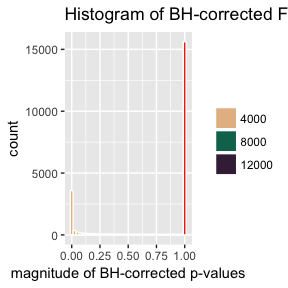

```r
plot(x = limmaTMLEout, type = "pvals_adj")
```

Setting the argument `type="pvals_raw"` will instead produce a histogram of the raw p-values *(these are less informative and should, in general, not be used for inferential purposes, as the computation producing these p-values ignores the multiple testing nature of the biomarker discovery problem)*:

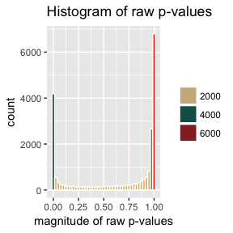

```r
plot(x = limmaTMLEout, type = "pvals_raw")
```

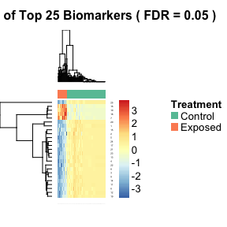

```r
heatmap_biotmle(x = limmaTMLEout, designMat = design, FDRcutoff = 0.05,
                top = 25)
```

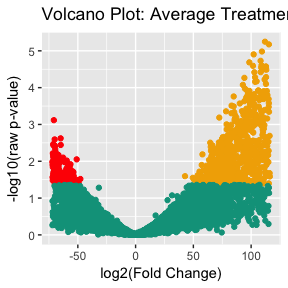

```r
volcano_biotmle(biotmle = limmaTMLEout)
```